# January 30

Intro: slide 167-169

# Packages

Install any of these that you don’t have already:

```r
options(tidyverse.quiet=T) # no messages!
library(tidyverse)
library(survival) # for analysis
library(survminer) # for graphs
```

# Dancing data

```r
my_url="http://www.utsc.utoronto.ca/~butler/d29/dancing.txt"
dance=read_table(my_url)
dance
```

| Months | Quit | Treatment | Age |
| --- | --- | --- | --- |
| 1 | 1 | 0 | 16 |
| 2 | 1 | 0 | 24 |
| 2 | 1 | 0 | 18 |
| 3 | 0 | 0 | 27 |
| 4 | 1 | 0 | 25 |
| 5 | 1 | 0 | 21 |
| 11 | 1 | 0 | 55 |
| 7 | 1 | 1 | 26 |
| 8 | 1 | 1 | 36 |
| 10 | 1 | 1 | 38 |

[output cut: 2 more lines]

- Does time spent dancing before quitting depend on treatment (visit to dance competition) or age?
- Some of the women quit dancing at the #months shown (`quit=1`), some were still dancing the last we knew (`quit=0`).
- Event of interest “quit dancing”
- Women who were never observed to quit called “censored”.
- Model has to accommodate censored individuals: there is information there, particularly if observed a long time and event still hasn’t happened.

## Modelling and response variable

Response variable first:

```r
mth=with(dance,Surv(Months,Quit))
mth
```

```
 [1]  1   2   2   3+  4   5  11   7   8  10  10+ 12
```

```r
dance %>% mutate(y=mth)
```

```
Error in mutate_impl(.data, dots) :
  Column `y` must be length 12 (the number of rows) or one, not 24
```

```r
cbind(mth, dance)
```

| mth | Months | Quit | Treatment | Age |
| --- | --- | --- | --- | --- |
| 1 | 1 | 1 | 0 | 16 |
| 2 | 2 | 1 | 0 | 24 |
| 2 | 2 | 1 | 0 | 18 |
| 3+ | 3 | 0 | 0 | 27 |
| 4 | 4 | 1 | 0 | 25 |
| 5 | 5 | 1 | 0 | 21 |
| 11 | 11 | 1 | 0 | 55 |
| 7 | 7 | 1 | 1 | 26 |
| 8 | 8 | 1 | 1 | 36 |
| 10 | 10 | 1 | 1 | 38 |

[output cut: 2 more lines]

that thing `mth`:

```r
print.default(mth)
```

```
      time status
 [1,]    1      1
 [2,]    2      1
 [3,]    2      1
 [4,]    3      0
 [5,]    4      1
 [6,]    5      1
 [7,]   11      1
 [8,]    7      1
 [9,]    8      1
[10,]   10      1
[11,]   10      0
[12,]   12      1
attr(,"type")
[1] "right"
attr(,"class")
[1] "Surv"
```

*actually* has two columns, so that this doesn’t work:

```r
dance %>% mutate(mth=mth)
```

## Cox proportional-hazards model

predict “survival time” (time until quitting dancing) from treatment and age, allowing for fact that some women never observed to quit.

We use $\alpha=0.10$, since data set is small.

```r
dance.1=coxph(mth~Treatment+Age,data=dance)
summary(dance.1)
```

```
Call:
coxph(formula = mth ~ Treatment + Age, data = dance)

  n= 12, number of events= 10

              coef exp(coef) se(coef)      z Pr(>|z|)
Treatment -4.44915   0.01169  2.60929 -1.705   0.0882 .
Age       -0.36619   0.69337  0.15381 -2.381   0.0173 *
---
Signif. codes:  0 ‘***’ 0.001 ‘**’ 0.01 ‘*’ 0.05 ‘.’ 0.1 ‘ ’ 1

          exp(coef) exp(-coef) lower .95 upper .95
Treatment   0.01169     85.554 7.026e-05    1.9444
Age         0.69337      1.442 5.129e-01    0.9373

Concordance= 0.964  (se = 0.125 )
Rsquare= 0.836   (max possible= 0.938 )
Likelihood ratio test= 21.68  on 2 df,   p=1.956e-05
Wald test            = 5.67  on 2 df,   p=0.0587
Score (logrank) test = 14.75  on 2 df,   p=0.0006274
```

Tests at bottom: *something* predicts time until quitting dancing.

Both treatment and age have a significant effect at $\alpha=0.10$. What kind of effect? Later.

## Model checking

“Martingale residuals”: look for no pattern with fitted values.

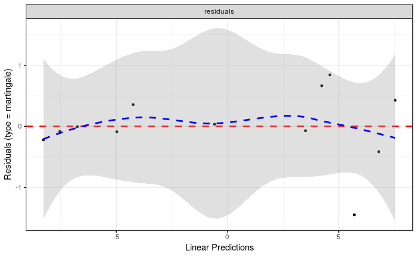

```r
ggcoxdiagnostics(dance.1)
```

Average residual is zero all way across: no problem.

Martingale residuals can go very negative, so don’t look at normal quantile plot of them.

## Predictions

To understand effect of age and treatment, do predictions and plot them.

Combos of age 20 and 40, dance competition and not (1 and 0):

```r
ages=c(20,40)
treatments=c(0,1)
new=crossing(Treatment=treatments, Age=ages)
View(new)
```

In a regression, run `predict`. In survival analysis, run `survfit`:

```r
s=survfit(dance.1,new,data=dance) # model, new data, original data
summary(s)
```

```
Call: survfit(formula = dance.1, newdata = new, data = dance)

 time n.risk n.event survival1 survival2 survival3 survival4
    1     12       1  8.76e-01  1.00e+00  9.98e-01     1.000
    2     11       2  3.99e-01  9.99e-01  9.89e-01     1.000
    4      8       1  1.24e-01  9.99e-01  9.76e-01     1.000
    5      7       1  2.93e-02  9.98e-01  9.60e-01     1.000
    7      6       1 2.96e-323  6.13e-01  1.70e-04     0.994
    8      5       1  0.00e+00  2.99e-06  1.35e-98     0.862
   10      4       1  0.00e+00  3.61e-20  0.00e+00     0.593
   11      2       1  0.00e+00  0.00e+00  0.00e+00     0.000
   12      1       1  0.00e+00  0.00e+00  0.00e+00     0.000
```

the four columns `survival` are the four combinations in the order they were in `new`.

Easier: make a graph:

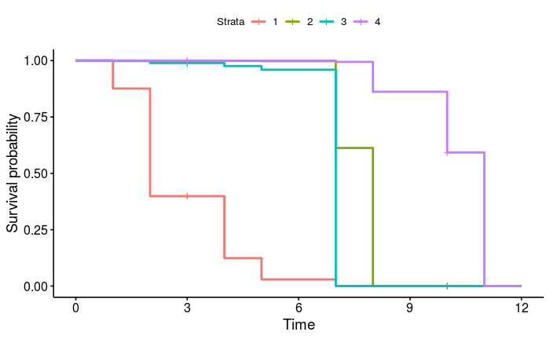

```r
ggsurvplot(s,conf.int=F)
```

It is better to have a higher chance of continuing to dance for longer (at least if you own a dance studio!) So being up and to the right is better (purple and not red).

Which of the strata is which? Same order as in `new`:

```r
new
```

[output not shown]

Purple stratum is #4, treatment 1 (going to dance comp) and age 40. These women continue to dance for longest.

Age effect is that older women continue to dance for longer, keeping treatment fixed (green better than red, purple better than blue).

Treatment effect is that women who go to the dance competition continue to dance for longer, keeping age fixed (blue better than red, purple better than green).

Go back to `summary` output:

```r
summary(dance.1)
```

```
Call:
coxph(formula = mth ~ Treatment + Age, data = dance)

  n= 12, number of events= 10

              coef exp(coef) se(coef)      z Pr(>|z|)
Treatment -4.44915   0.01169  2.60929 -1.705   0.0882 .
Age       -0.36619   0.69337  0.15381 -2.381   0.0173 *
---
Signif. codes:  0 ‘***’ 0.001 ‘**’ 0.01 ‘*’ 0.05 ‘.’ 0.1 ‘ ’ 1

          exp(coef) exp(-coef) lower .95 upper .95
Treatment   0.01169     85.554 7.026e-05    1.9444
Age         0.69337      1.442 5.129e-01    0.9373

Concordance= 0.964  (se = 0.125 )
Rsquare= 0.836   (max possible= 0.938 )
Likelihood ratio test= 21.68  on 2 df,   p=1.956e-05
Wald test            = 5.67  on 2 df,   p=0.0587
Score (logrank) test = 14.75  on 2 df,   p=0.0006274
```

The coefficients are on the scale of “hazard of event”: if positive, makes the event more likely to happen sooner, if negative, event is less likely to happen sooner (more likely to take a long time).

Here, coefficients are both negative. That means:

- a woman who goes to the dance competition is less likely to quit soon (more likely to dance for a long time)
- a woman who is older is less likely to quit soon (more likely to dance longer).

# Lung cancer example

The variables: slide 183, all quantitative (except for `inst`, a label, and `status`, `sex`, categorical variables with 2 levels treated as numbers).

```r
lung
```

|  | inst | time | status | age | sex | ph.ecog | ph.karno | pat.karno | meal.cal | wt.loss |
| --- | --- | --- | --- | --- | --- | --- | --- | --- | --- | --- |
| 1 | 3 | 306 | 2 | 74 | 1 | 1 | 90 | 100 | 1175 | NA |
| 2 | 3 | 455 | 2 | 68 | 1 | 0 | 90 | 90 | 1225 | 15 |
| 3 | 3 | 1010 | 1 | 56 | 1 | 0 | 90 | 90 | NA | 15 |
| 4 | 5 | 210 | 2 | 57 | 1 | 1 | 90 | 60 | 1150 | 11 |
| 5 | 1 | 883 | 2 | 60 | 1 | 0 | 100 | 90 | NA | 0 |
| 6 | 12 | 1022 | 1 | 74 | 1 | 1 | 50 | 80 | 513 | 0 |
| 7 | 7 | 310 | 2 | 68 | 2 | 2 | 70 | 60 | 384 | 10 |
| 8 | 11 | 361 | 2 | 71 | 2 | 2 | 60 | 80 | 538 | 1 |
| 9 | 1 | 218 | 2 | 53 | 1 | 1 | 70 | 80 | 825 | 16 |
| 10 | 7 | 166 | 2 | 61 | 1 | 2 | 70 | 70 | 271 | 34 |

[output cut: 218 more lines]

## Remove missing values

There are missing values. How many?

```r
summary(lung)
```

```
      inst            time            status           age             sex           ph.ecog
 Min.   : 1.00   Min.   :   5.0   Min.   :1.000   Min.   :39.00   Min.   :1.000   Min.   :0.0000
 1st Qu.: 3.00   1st Qu.: 166.8   1st Qu.:1.000   1st Qu.:56.00   1st Qu.:1.000   1st Qu.:0.0000
 Median :11.00   Median : 255.5   Median :2.000   Median :63.00   Median :1.000   Median :1.0000
 Mean   :11.09   Mean   : 305.2   Mean   :1.724   Mean   :62.45   Mean   :1.395   Mean   :0.9515
 3rd Qu.:16.00   3rd Qu.: 396.5   3rd Qu.:2.000   3rd Qu.:69.00   3rd Qu.:2.000   3rd Qu.:1.0000
 Max.   :33.00   Max.   :1022.0   Max.   :2.000   Max.   :82.00   Max.   :2.000   Max.   :3.0000
 NA's   :1                                                                        NA's   :1
    ph.karno        pat.karno         meal.cal         wt.loss
 Min.   : 50.00   Min.   : 30.00   Min.   :  96.0   Min.   :-24.000
 1st Qu.: 75.00   1st Qu.: 70.00   1st Qu.: 635.0   1st Qu.:  0.000
 Median : 80.00   Median : 80.00   Median : 975.0   Median :  7.000
 Mean   : 81.94   Mean   : 79.96   Mean   : 928.8   Mean   :  9.832
 3rd Qu.: 90.00   3rd Qu.: 90.00   3rd Qu.:1150.0   3rd Qu.: 15.750
 Max.   :100.00   Max.   :100.00   Max.   :2600.0   Max.   : 68.000
 NA's   :1        NA's   :3        NA's   :47       NA's   :14
```

Some variables have a lot.

Get rid of cases with missing values

```r
(lung %>% drop_na() -> lung.complete)
```

|  | inst | time | status | age | sex | ph.ecog | ph.karno | pat.karno | meal.cal | wt.loss |
| --- | --- | --- | --- | --- | --- | --- | --- | --- | --- | --- |
| 2 | 3 | 455 | 2 | 68 | 1 | 0 | 90 | 90 | 1225 | 15 |
| 4 | 5 | 210 | 2 | 57 | 1 | 1 | 90 | 60 | 1150 | 11 |
| 6 | 12 | 1022 | 1 | 74 | 1 | 1 | 50 | 80 | 513 | 0 |
| 7 | 7 | 310 | 2 | 68 | 2 | 2 | 70 | 60 | 384 | 10 |
| 8 | 11 | 361 | 2 | 71 | 2 | 2 | 60 | 80 | 538 | 1 |
| 9 | 1 | 218 | 2 | 53 | 1 | 1 | 70 | 80 | 825 | 16 |
| 10 | 7 | 166 | 2 | 61 | 1 | 2 | 70 | 70 | 271 | 34 |
| 11 | 6 | 170 | 2 | 57 | 1 | 1 | 80 | 80 | 1025 | 27 |
| 15 | 12 | 567 | 2 | 57 | 1 | 1 | 80 | 70 | 2600 | 60 |
| 17 | 22 | 613 | 2 | 70 | 1 | 1 | 90 | 100 | 1150 | -5 |

[output cut: 157 more lines]

Any missing values left?

```r
summary(lung.complete)
```

```
      inst            time            status           age             sex           ph.ecog
 Min.   : 1.00   Min.   :   5.0   Min.   :1.000   Min.   :39.00   Min.   :1.000   Min.   :0.0000
 1st Qu.: 3.00   1st Qu.: 174.5   1st Qu.:1.000   1st Qu.:57.00   1st Qu.:1.000   1st Qu.:0.0000
 Median :11.00   Median : 268.0   Median :2.000   Median :64.00   Median :1.000   Median :1.0000
 Mean   :10.71   Mean   : 309.9   Mean   :1.719   Mean   :62.57   Mean   :1.383   Mean   :0.9581
 3rd Qu.:15.00   3rd Qu.: 419.5   3rd Qu.:2.000   3rd Qu.:70.00   3rd Qu.:2.000   3rd Qu.:1.0000
 Max.   :32.00   Max.   :1022.0   Max.   :2.000   Max.   :82.00   Max.   :2.000   Max.   :3.0000
    ph.karno        pat.karno         meal.cal         wt.loss
 Min.   : 50.00   Min.   : 30.00   Min.   :  96.0   Min.   :-24.000
 1st Qu.: 70.00   1st Qu.: 70.00   1st Qu.: 619.0   1st Qu.:  0.000
 Median : 80.00   Median : 80.00   Median : 975.0   Median :  7.000
 Mean   : 82.04   Mean   : 79.58   Mean   : 929.1   Mean   :  9.719
 3rd Qu.: 90.00   3rd Qu.: 90.00   3rd Qu.:1162.5   3rd Qu.: 15.000
 Max.   :100.00   Max.   :100.00   Max.   :2600.0   Max.   : 68.000
```

No. We are good.

## Create response variable and fit Cox model

Create response variable. Use `time` (survival time) and `status`. Check data description to see that 2 means “event happened” (death). These times are days.

```r
y=with(lung.complete, Surv(time, status==2))
y
```

```
  [1]  455   210  1022+  310   361   218   166   170   567   613   707    61   301    81   371   520
 [17]  574   118   390    12   473    26   107    53   814   965+   93   731   460   153   433   583
 [33]   95   303   519   643   765    53   246   689     5   687   345   444   223    60   163    65
 [49]  821+  428   230   840+  305    11   226   426   705   363   176   791    95   196+  167   806+
 [65]  284   641   147   740+  163   655    88   245    30   477   559+  450   156   529+  429   351
 [81]   15   181   283    13   212   524   288   363   199   550    54   558   207    92    60   551+
 [97]  293   353   267   511+  457   337   201   404+  222    62   458+  353   163    31   229   156
[113]  291   179   376+  384+  268   292+  142   413+  266+  320   181   285   301+  348   197   382+
[129]  303+  296+  180   145   269+  300+  284+  292+  332+  285   259+  110   286   270   225+  269
[145]  225+  243+  276+  135    79    59   240+  202+  235+  239   252+  221+  185+  222+  183   211+
[161]  175+  197+  203+  191+  105+  174+  177+
```

As a check, usually the longer survival times go with survival/censoring:

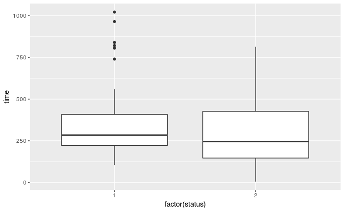

```r
ggplot(lung.complete, aes(x=factor(status), y=time))+geom_boxplot()
```

1 was lived, 2 was died.

## Cox model

`inst` is label for “institution”, ignore.

To start, use all the other variables we haven’t used as explanatory. This means using everything except `inst`, `time`, `status`.

```r
lung.1=coxph(y~.-inst-time-status, data=lung.complete)
summary(lung.1)
```

```
Call:
coxph(formula = y ~ . - inst - time - status, data = lung.complete)

  n= 167, number of events= 120

                coef  exp(coef)   se(coef)      z Pr(>|z|)
age        1.080e-02  1.011e+00  1.160e-02  0.931  0.35168
sex       -5.536e-01  5.749e-01  2.016e-01 -2.746  0.00603 **
ph.ecog    7.395e-01  2.095e+00  2.250e-01  3.287  0.00101 **
ph.karno   2.244e-02  1.023e+00  1.123e-02  1.998  0.04575 *
pat.karno -1.207e-02  9.880e-01  8.116e-03 -1.488  0.13685
meal.cal   2.835e-05  1.000e+00  2.594e-04  0.109  0.91298
wt.loss   -1.420e-02  9.859e-01  7.766e-03 -1.828  0.06748 .
---
Signif. codes:  0 ‘***’ 0.001 ‘**’ 0.01 ‘*’ 0.05 ‘.’ 0.1 ‘ ’ 1

          exp(coef) exp(-coef) lower .95 upper .95
age          1.0109     0.9893    0.9881    1.0341
sex          0.5749     1.7395    0.3872    0.8534
ph.ecog      2.0950     0.4773    1.3479    3.2560
ph.karno     1.0227     0.9778    1.0004    1.0455
pat.karno    0.9880     1.0121    0.9724    1.0038
meal.cal     1.0000     1.0000    0.9995    1.0005
wt.loss      0.9859     1.0143    0.9710    1.0010

Concordance= 0.653  (se = 0.031 )
Rsquare= 0.155   (max possible= 0.998 )
Likelihood ratio test= 28.16  on 7 df,   p=0.0002053
Wald test            = 27.5  on 7 df,   p=0.0002711
Score (logrank) test = 28.31  on 7 df,   p=0.0001929
```

There are some significant variables and some non-significant ones.

Suggests `step` with backward elimination to get a better model:

```r
lung.2=step(lung.1, test="Chisq",trace=1)
```

```
Start:  AIC=1002.07
y ~ (inst + time + status + age + sex + ph.ecog + ph.karno +
    pat.karno + meal.cal + wt.loss) - inst - time - status

            Df    AIC     LRT  Pr(>Chi)
- meal.cal   1 1000.1  0.0119 0.9131696
- age        1 1001.0  0.8806 0.3480390
<none>         1002.1
- pat.karno  1 1002.3  2.1966 0.1383176
- wt.loss    1 1003.6  3.5303 0.0602570 .
- ph.karno   1 1004.3  4.2102 0.0401822 *
- sex        1 1008.0  7.9327 0.0048550 **
- ph.ecog    1 1011.1 11.0256 0.0008986 ***
---
Signif. codes:  0 ‘***’ 0.001 ‘**’ 0.01 ‘*’ 0.05 ‘.’ 0.1 ‘ ’ 1

Step:  AIC=1000.08
y ~ age + sex + ph.ecog + ph.karno + pat.karno + wt.loss

            Df     AIC     LRT  Pr(>Chi)
- age        1  998.95  0.8714 0.3505744
<none>         1000.08
- pat.karno  1 1000.29  2.2073 0.1373553
- wt.loss    1 1001.60  3.5196 0.0606477 .
- ph.karno   1 1002.28  4.2018 0.0403808 *
- sex        1 1006.29  8.2053 0.0041769 **
- ph.ecog    1 1009.09 11.0138 0.0009043 ***
---
Signif. codes:  0 ‘***’ 0.001 ‘**’ 0.01 ‘*’ 0.05 ‘.’ 0.1 ‘ ’ 1

Step:  AIC=998.95
y ~ sex + ph.ecog + ph.karno + pat.karno + wt.loss

            Df     AIC     LRT  Pr(>Chi)
<none>          998.95
- pat.karno  1  999.34  2.3857 0.1224475
- ph.karno   1 1000.53  3.5777 0.0585597 .
- wt.loss    1 1000.74  3.7830 0.0517750 .
- sex        1 1005.25  8.2948 0.0039758 **
- ph.ecog    1 1007.83 10.8746 0.0009749 ***
---
Signif. codes:  0 ‘***’ 0.001 ‘**’ 0.01 ‘*’ 0.05 ‘.’ 0.1 ‘ ’ 1
```

```r
summary(lung.2)
```

```
Call:
coxph(formula = y ~ sex + ph.ecog + ph.karno + pat.karno + wt.loss,
    data = lung.complete)

  n= 167, number of events= 120

               coef exp(coef)  se(coef)      z Pr(>|z|)
sex       -0.558190  0.572244  0.199202 -2.802  0.00508 **
ph.ecog    0.742983  2.102197  0.227604  3.264  0.00110 **
ph.karno   0.020366  1.020575  0.011080  1.838  0.06604 .
pat.karno -0.012401  0.987675  0.007978 -1.554  0.12008
wt.loss   -0.014494  0.985611  0.007693 -1.884  0.05957 .
---
Signif. codes:  0 ‘***’ 0.001 ‘**’ 0.01 ‘*’ 0.05 ‘.’ 0.1 ‘ ’ 1

          exp(coef) exp(-coef) lower .95 upper .95
sex          0.5722     1.7475    0.3873    0.8456
ph.ecog      2.1022     0.4757    1.3457    3.2841
ph.karno     1.0206     0.9798    0.9987    1.0430
pat.karno    0.9877     1.0125    0.9724    1.0032
wt.loss      0.9856     1.0146    0.9709    1.0006

Concordance= 0.658  (se = 0.031 )
Rsquare= 0.151   (max possible= 0.998 )
Likelihood ratio test= 27.28  on 5 df,   p=5.028e-05
Wald test            = 26.89  on 5 df,   p=5.987e-05
Score (logrank) test = 27.64  on 5 df,   p=4.285e-05
```

I make the call that I’m only going to keep `sex` and `ph.ecog` and take out the other three:

```r
lung.3=update(lung.2, .~.-ph.karno-pat.karno-wt.loss)
summary(lung.3)
```

```
Call:
coxph(formula = y ~ sex + ph.ecog, data = lung.complete)

  n= 167, number of events= 120

           coef exp(coef) se(coef)      z Pr(>|z|)
sex     -0.5101    0.6004   0.1969 -2.591 0.009579 **
ph.ecog  0.4825    1.6201   0.1323  3.647 0.000266 ***
---
Signif. codes:  0 ‘***’ 0.001 ‘**’ 0.01 ‘*’ 0.05 ‘.’ 0.1 ‘ ’ 1

        exp(coef) exp(-coef) lower .95 upper .95
sex        0.6004     1.6655    0.4082    0.8832
ph.ecog    1.6201     0.6172    1.2501    2.0998

Concordance= 0.641  (se = 0.03 )
Rsquare= 0.11   (max possible= 0.998 )
Likelihood ratio test= 19.48  on 2 df,   p=5.882e-05
Wald test            = 19.35  on 2 df,   p=6.297e-05
Score (logrank) test = 19.62  on 2 df,   p=5.493e-05
```

Interpretation: - a larger `sex` number (female=2) is less likely to die sooner - a larger score on `ph.ecog` scale means *more* likely to die sooner.

## Should I have taken out all those variables?

```r
anova(lung.3, lung.1)
```

```
Analysis of Deviance Table
 Cox model: response is  y
 Model 1: ~ sex + ph.ecog
 Model 2: ~ (inst + time + status + age + sex + ph.ecog + ph.karno + pat.karno + meal.cal + wt.loss) - inst - time - status
   loglik  Chisq Df P(>|Chi|)
1 -498.38
2 -494.03 8.6825  5    0.1224
```

yes, I was justified in removing them all.

## Predictions and graph

Make combinations of sexes and `ph.ecog` scores:

```r
sexes=c(1,2)
ph.ecogs=0:3
lung.new=crossing(sex=sexes,ph.ecog=ph.ecogs)
View(lung.new)
```

Predict:

```r
summary(s)
```

[output not shown]

[output cut: 79 more lines]

Plot them:

```r
ggsurvplot(s,conf.int=F)
```

[output not shown]

```r
summary(lung.3)
```

```
Call:
coxph(formula = y ~ sex + ph.ecog, data = lung.complete)

  n= 167, number of events= 120

           coef exp(coef) se(coef)      z Pr(>|z|)
sex     -0.5101    0.6004   0.1969 -2.591 0.009579 **
ph.ecog  0.4825    1.6201   0.1323  3.647 0.000266 ***
---
Signif. codes:  0 ‘***’ 0.001 ‘**’ 0.01 ‘*’ 0.05 ‘.’ 0.1 ‘ ’ 1

        exp(coef) exp(-coef) lower .95 upper .95
sex        0.6004     1.6655    0.4082    0.8832
ph.ecog    1.6201     0.6172    1.2501    2.0998

Concordance= 0.641  (se = 0.03 )
Rsquare= 0.11   (max possible= 0.998 )
Likelihood ratio test= 19.48  on 2 df,   p=5.882e-05
Wald test            = 19.35  on 2 df,   p=6.297e-05
Score (logrank) test = 19.62  on 2 df,   p=5.493e-05
```

## Martingale residuals

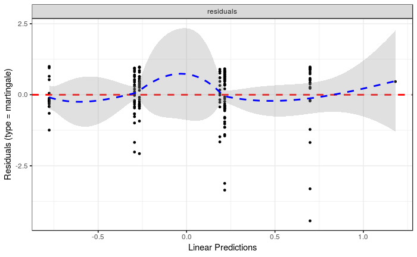

```r
ggcoxdiagnostics(lung.3)
```

Grey envelope includes 0 all the way across, so I call this good.

# When the Cox model fails

Invent some data:

```r
age=seq(20,60,5)
survtime=c(10,12,11,21,15,20,8,9,11)
stat=c(1,1,1,1,0,1,1,1,1)
d=tibble(age,survtime,stat)
y=with(d,Surv(survtime,stat==1))
cbind(y,d)
```

| y | age | survtime | stat |
| --- | --- | --- | --- |
| 10 | 20 | 10 | 1 |
| 12 | 25 | 12 | 1 |
| 11 | 30 | 11 | 1 |
| 21 | 35 | 21 | 1 |
| 15+ | 40 | 15 | 0 |
| 20 | 45 | 20 | 1 |
| 8 | 50 | 8 | 1 |
| 9 | 55 | 9 | 1 |
| 11 | 60 | 11 | 1 |

Survival time 15 was actually censored, so would have been larger if survival time observed.

Fit model:

```r
y.1=coxph(y~age,data=d)
summary(y.1)
```

```
Call:
coxph(formula = y ~ age, data = d)

  n= 9, number of events= 8

       coef exp(coef) se(coef)     z Pr(>|z|)
age 0.01984   1.02003  0.03446 0.576    0.565

    exp(coef) exp(-coef) lower .95 upper .95
age      1.02     0.9804    0.9534     1.091

Concordance= 0.545  (se = 0.146 )
Rsquare= 0.036   (max possible= 0.926 )
Likelihood ratio test= 0.33  on 1 df,   p=0.5669
Wald test            = 0.33  on 1 df,   p=0.5649
Score (logrank) test = 0.33  on 1 df,   p=0.563
```

Model and effect of age *not significant*.

Look at martingale residual plot:

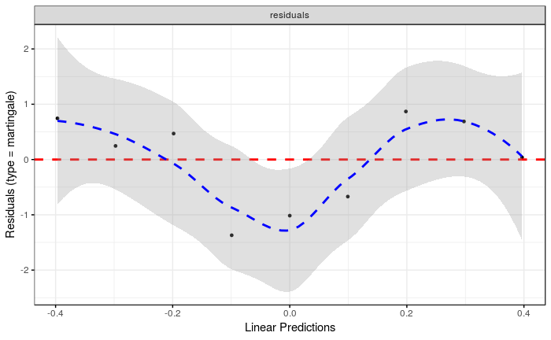

```r
ggcoxdiagnostics(y.1)
```

Down and up quadratic trend. Suggests adding squared term in age:

```r
y.2=coxph(y~age+I(age^2),data=d)
summary(y.2)
```

```
Call:
coxph(formula = y ~ age + I(age^2), data = d)

  n= 9, number of events= 8

              coef exp(coef)  se(coef)      z Pr(>|z|)
age      -0.380184  0.683736  0.241617 -1.573   0.1156
I(age^2)  0.004832  1.004844  0.002918  1.656   0.0977 .
---
Signif. codes:  0 ‘***’ 0.001 ‘**’ 0.01 ‘*’ 0.05 ‘.’ 0.1 ‘ ’ 1

         exp(coef) exp(-coef) lower .95 upper .95
age         0.6837     1.4626    0.4258     1.098
I(age^2)    1.0048     0.9952    0.9991     1.011

Concordance= 0.758  (se = 0.146 )
Rsquare= 0.304   (max possible= 0.926 )
Likelihood ratio test= 3.26  on 2 df,   p=0.1964
Wald test            = 3.16  on 2 df,   p=0.2058
Score (logrank) test = 3.75  on 2 df,   p=0.1536
```

Squared term almost significant, and

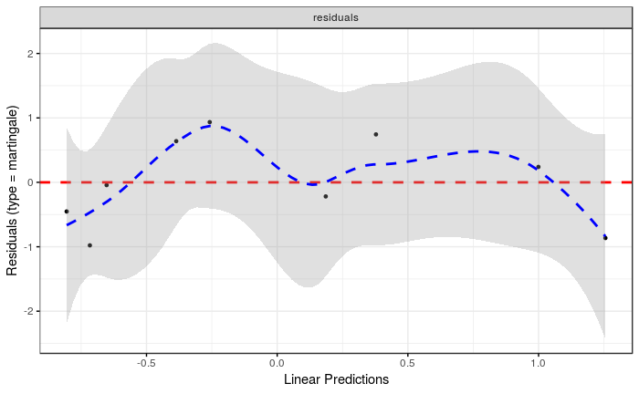

```r
ggcoxdiagnostics(y.2)
```

martingale residual plot improved.

What do predictions look like?

```r
new=tibble(age=seq(20,60,10))
new
```

| age |
| --- |
| 20 |
| 30 |
| 40 |
| 50 |
| 60 |

```r
s=survfit(y.2, new, data=d)
```

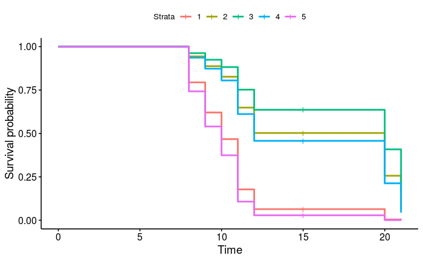

```r
ggsurvplot(s,conf.int=F)
```

```r
new
```

| age |
| --- |
| 20 |
| 30 |
| 40 |
| 50 |
| 60 |

Best survival associated with stratum 3, middling age 40.

Much worse survival for two extreme ages 20 and 60.